# Deconstructing Predictive Policing Algorithms

Laura Frances, University of Pennsylvania

10/17/2023

# **Lab Objective**

The primary objective of this lab is to construct a spatial risk model that suffers from significant selection bias to visualize potential fault lines of predictive algorithms. Going ‘under the hood’ of predictive policing algorithms is essential to combating the practice’s well-documented contribution to the over-policing of non-white neighborhoods and the subsequent disproportionate arrest of non-white residents.

For more about how predictive policing is racist and why we must demand transparency, check out this July 2020 piece by Will Douglas Heaven in the MIT Technology Review: [(*Predictive policing algorithms are racist. They need to be dismantled.*)](https://www.technologyreview.com/2020/07/17/1005396/predictive-policing-algorithms-racist-dismantled-machine-learning-bias-criminal-justice/)

# **Data Wrangling and Feature Engineering**

## Visualizing Spatial Bias

Black Americans are nearly 3.5 times more likely to be arrests for cannabis possession, although, cannabis usage is equally used between black and white Americans. [(Brookings Institute)](https://www.brookings.edu/articles/trump-won-white-voters-but-serious-inequities-remain-for-black-americans/)In Chicago, the chasm is even wider. Of the approximate 3,200 cannabis-related arrests, nearly 75% of those arrests are black residents despite only making up only 29% of the total population. The criminalization of drug use is racialized. Therefore, selection bias is an issue when evaluating cannabis-related arrests in a US city, particularly in one as racially segregated as Chicago. Unsurprisingly, the density of arrests (Figure 1.2) aligns with the city’s racial context (Figure 3.4). Selecting areas with high arrest rates to predict where police need to patrol perpetuates a cycle of disproportionate policing in nonwhite areas.

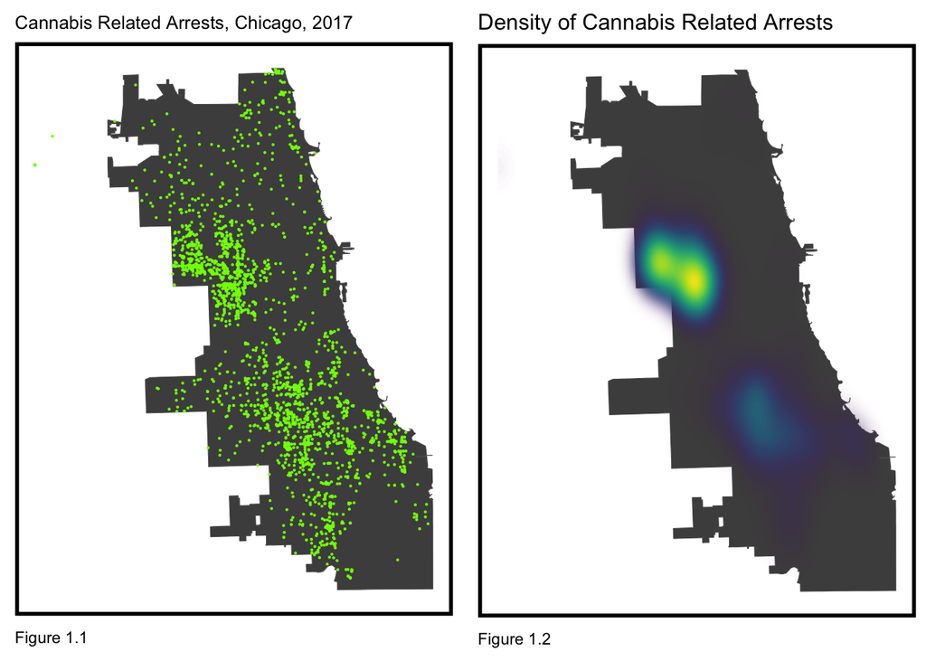

```r
policeDistricts <-
  st_read("https://data.cityofchicago.org/api/geospatial/fthy-xz3r?method=export&format=GeoJSON") %>%
  st_transform('ESRI:102271') %>%
  dplyr::select(District = dist_num)

policeBeats <-
  st_read("https://data.cityofchicago.org/api/geospatial/aerh-rz74?method=export&format=GeoJSON") %>%
  st_transform('ESRI:102271') %>%
  dplyr::select(District = beat_num)

chicagoBoundary <-
  st_read(file.path(root.dir,"/Chapter5/chicagoBoundary.geojson")) %>%
  st_transform('ESRI:102271')

bothPoliceUnits <- rbind(mutate(policeDistricts, Legend = "Police Districts"),
                         mutate(policeBeats, Legend = "Police Beats"))

crimes <- read.socrata("https://data.cityofchicago.org/Public-Safety/Crimes-2017/d62x-nvdr")

#filter data for cannabis related crimes

narc <- crimes %>%
    filter(Primary.Type == "NARCOTICS" & str_detect(Description, "CANNABIS")) %>%
    mutate(x = gsub("[()]", "", Location)) %>%
    separate(x,into= c("Y","X"), sep=",") %>%
    mutate(X = as.numeric(X),Y = as.numeric(Y)) %>%
    na.omit() %>%
    st_as_sf(coords = c("X", "Y"), crs = 4326, agr = "constant")%>%
    st_transform('ESRI:102271') %>%
    distinct()

grid.arrange(ncol=2,
ggplot() +
  geom_sf(data = chicagoBoundary, fill = "grey30") +
  geom_sf(data = narc, colour="chartreuse", size=0.1, show.legend = "point") +
  labs(title= "Cannabis Related Arrests, Chicago, 2017", caption = "Figure 1.1") +
  mapTheme(title_size = 10),

ggplot() +
  geom_sf(data = chicagoBoundary, fill = "grey30") +
  stat_density2d(data = data.frame(st_coordinates(narc)),
                 aes(X, Y, fill = ..level.., alpha = ..level..),
                 size = 0.01, bins = 75, geom = 'polygon') + #increased number bins
  scale_fill_viridis() +
  scale_alpha(range = c(0.00, 0.35), guide = FALSE) +
  labs(title = "Density of Cannabis Related Arrests", caption = "Figure 1.2") +
  mapTheme(title_size = 12) + theme(legend.position = "none"))
```

## Fishnet Grid

The fishnet grid is composed of 500 by 500 feet cells. In 2017, there were 3231 cannbis-related arrests. This fishnet grid pinpoints hotspots, with the most visible spots seeing at least 50 arrests.

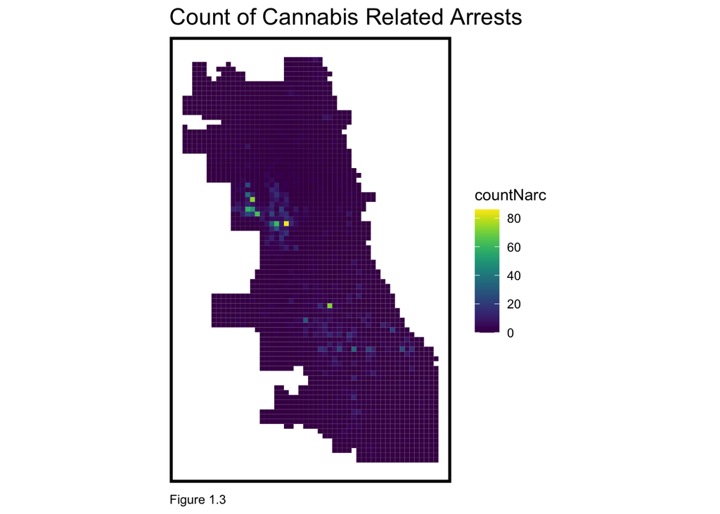

```r
## using {sf} to create the grid

fishnet <-
  st_make_grid(chicagoBoundary,
               cellsize = 500,
               square = TRUE) %>%
  .[chicagoBoundary] %>%            # fast way to select intersecting polygons
  st_sf() %>%
  mutate(uniqueID = 1:n())

crime_net <-
  dplyr::select(narc) %>%
  mutate(countNarc = 1) %>%
  aggregate(., fishnet, sum) %>%
  mutate(countNarc = replace_na(countNarc, 0),
         uniqueID = 1:n(),
         cvID = sample(round(nrow(fishnet) / 24),
                       size=nrow(fishnet), replace = TRUE))

ggplot() +
  geom_sf(data = crime_net, aes(fill = countNarc), color = NA) +
  scale_fill_viridis() +
  labs(title = "Count of Cannabis Related Arrests", caption = "Figure 1.3") +
  mapTheme()
```

## Risk Factors: Count

Other variables that were studied and omitted from this study include: parks, churches, and nursing home which are also part of Chicago’s drug free zone criteria. A Chicago Police Department (CPD) report of Traffic stops was also considered, however, its location anonymization did not provide enough fidelity to include in this study.

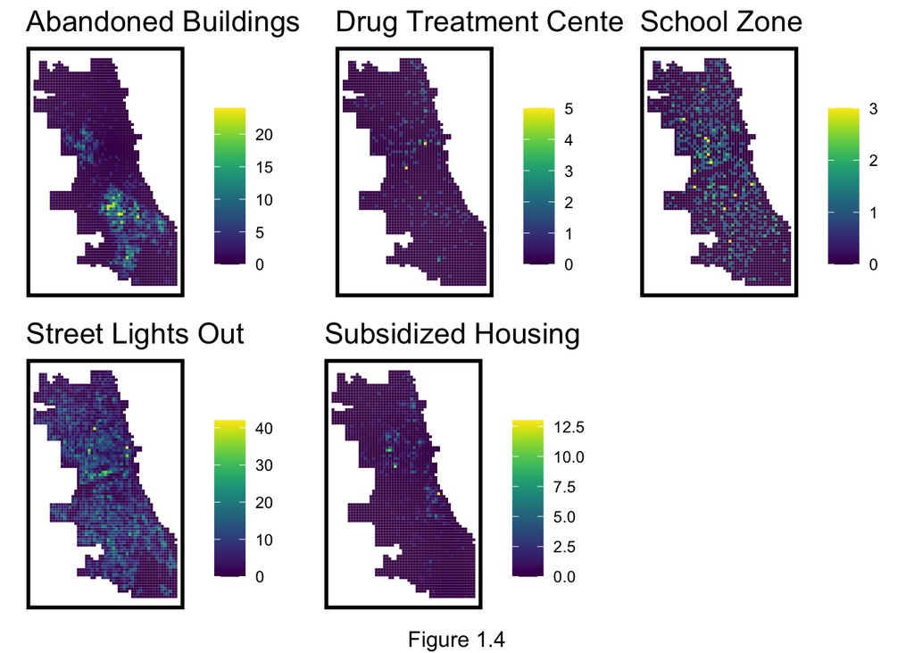

```r
schools <-
    read.socrata("https://data.cityofchicago.org/resource/d2h8-2upd.json") %>% #School locations from SY17-18
    dplyr::select(Y = lat, X = long) %>%
    na.omit() %>%
    st_as_sf(coords = c("X", "Y"), crs = 4326, agr = "constant") %>%
    st_transform(st_crs(fishnet)) %>%
    # st_buffer(dist = 1000) %>% # Add a 1000ft buffer as part of "drug free zone" reg
    mutate(Legend = "School Zone")

affordableHousing <-
    read.socrata("https://data.cityofchicago.org/resource/s6ha-ppgi.json") %>%
    dplyr::select(Y = latitude, X = longitude) %>%
    na.omit() %>%
    st_as_sf(coords = c("X", "Y"), crs = 4326, agr = "constant") %>%
    st_transform(st_crs(fishnet)) %>%
    # st_buffer(dist = 1000) %>% # Add a 1000ft buffer as part of "drug free zone" reg
    mutate(Legend = "Subsidized Housing")

treatmentCenters <-
    read.socrata("https://data.cityofchicago.org/resource/232q-2cqr.json") %>%
    dplyr::select(Y = physical_address.latitude, X = physical_address.longitude) %>%
    na.omit() %>%
    st_as_sf(coords = c("X", "Y"), crs = 4326, agr = "constant") %>%
    st_transform(st_crs(fishnet)) %>%
    # st_buffer(dist = 1000) %>% # Add a 1000ft buffer as part of "drug free zone" reg
    mutate(Legend = "Drug Treatment Centers")

abandonBuildings <-
  read.socrata("https://data.cityofchicago.org/Service-Requests/311-Service-Requests-Vacant-and-Abandoned-Building/7nii-7srd") %>%
    mutate(year = substr(date_service_request_was_received,1,4)) %>%  filter(year == "2017") %>%
    dplyr::select(Y = latitude, X = longitude) %>%
    na.omit() %>%
    st_as_sf(coords = c("X", "Y"), crs = 4326, agr = "constant") %>%
    st_transform(st_crs(fishnet)) %>%
    mutate(Legend = "Abandoned Buildings")

streetLightsOut <-
  read.socrata("https://data.cityofchicago.org/Service-Requests/311-Service-Requests-Street-Lights-All-Out/zuxi-7xem") %>%
    mutate(year = substr(creation_date,1,4)) %>% filter(year == "2017") %>%
    dplyr::select(Y = latitude, X = longitude) %>%
    na.omit() %>%
    st_as_sf(coords = c("X", "Y"), crs = 4326, agr = "constant") %>%
    st_transform(st_crs(fishnet)) %>%
    mutate(Legend = "Street Lights Out")

## Neighborhoods to use in LOOCV in a bit
neighborhoods <-
  st_read("https://raw.githubusercontent.com/blackmad/neighborhoods/master/chicago.geojson") %>%
  st_transform(st_crs(fishnet))

# Vars_Net
vars_net <-
  rbind(schools, affordableHousing, treatmentCenters, abandonBuildings, streetLightsOut) %>% #NEED TO ADD ANOTHER?
  st_join(., fishnet, join=st_intersects) %>% #Changed to st_intersects
  st_drop_geometry() %>%
  group_by(uniqueID, Legend) %>%
  summarize(count = n()) %>%
    full_join(fishnet) %>%
    spread(Legend, count, fill=0) %>%
    st_sf() %>%
    dplyr::select(-`<NA>`) %>%
    na.omit() %>%
    ungroup()

## Plot the Risk Factors by Fishnet
vars_net.long <-
  gather(vars_net, Variable, value, -geometry, -uniqueID)

vars <- unique(vars_net.long$Variable)
mapList <- list()

for(i in vars){
  mapList[[i]] <-
    ggplot() +
    geom_sf(data = filter(vars_net.long, Variable == i), aes(fill=value), colour=NA) +
    scale_fill_viridis(name="") +
    labs(title=i) +
    mapTheme()}

do.call(grid.arrange,c(mapList, ncol =3, bottom = "Figure 1.4"))
```

## Risk Factors: NN

Since the grid cell imposes a rigid spatial scale of exposure, calculating the average ‘nearest neighbor’ distance to the risk factor hypothesizes a smoother exposure relationship across space. This study takes the average of 3 risk factor points nearest to a centroid point, which was determined to be the most legible definition of scale.

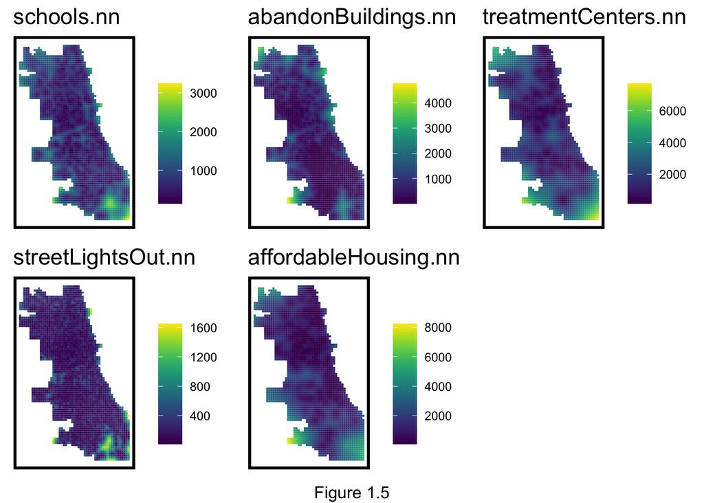

```r
vars_net <- vars_net %>%
  mutate(schools.nn = nn_function(st_coordinates(st_centroid(vars_net)), st_coordinates(schools), k = 3),
      abandonBuildings.nn = nn_function(st_coordinates(st_centroid(vars_net)), st_coordinates(abandonBuildings), k = 3),
      treatmentCenters.nn = nn_function(st_coordinates(st_centroid(vars_net)), st_coordinates(treatmentCenters), k = 3),
      streetLightsOut.nn = nn_function(st_coordinates(st_centroid(vars_net)), st_coordinates(streetLightsOut), k = 3),
      affordableHousing.nn = nn_function(st_coordinates(st_centroid(vars_net)), st_coordinates(affordableHousing), k= 3))

vars_net.long.nn <-
  dplyr::select(vars_net, ends_with(".nn")) %>%
    gather(Variable, value, -geometry)
vars <- unique(vars_net.long.nn$Variable)
mapList <- list()

for(i in vars){
  mapList[[i]] <-
    ggplot() +
      geom_sf(data = filter(vars_net.long.nn, Variable == i), aes(fill=value), colour=NA) +
      scale_fill_viridis(name="") +
      labs(title=i) +
      mapTheme()}

do.call(grid.arrange,c(mapList, ncol = 3, bottom = "Figure 1.5"))
```

```r
final_net <-
  left_join(crime_net, st_drop_geometry(vars_net), by="uniqueID")

final_net <-
  st_centroid(final_net) %>%
    st_join(dplyr::select(neighborhoods, name), by = "uniqueID") %>%
    st_join(dplyr::select(policeDistricts, District), by = "uniqueID") %>%
      st_drop_geometry() %>%
      left_join(dplyr::select(final_net, geometry, uniqueID)) %>%
      st_sf() %>%
  na.omit()
```

# **Exploring Spatial Process**

## Moran’s I

A local Moran’s I statistic is used to test the null hypothesis that the cannabis-related arrest count at a given location is randomly distributed relative to its immediate neighbors. The data visually suggests that where the count of arrests is highest, the local Moran’s I is too, therefore rejecting the null hypothesis and confirming that arrests are not randomly distributed. The low p-value suggests that in arrest hotspots the data is statistically significant.

```r
set.ZeroPolicyOption(TRUE)
final_net.nb <- poly2nb(as_Spatial(final_net), queen=TRUE)
final_net.weights <- nb2listw(final_net.nb, style="W", zero.policy=TRUE)

## see ?localmoran
local_morans <- localmoran(final_net$countNarc, final_net.weights, zero.policy=TRUE) %>%
  as.data.frame()

# join local Moran's I results to fishnet
final_net.localMorans <-
  cbind(local_morans, as.data.frame(final_net)) %>%
  st_sf() %>%
  dplyr::select(Narcotics_Count = countNarc,
                Local_Morans_I = Ii,
                P_Value = `Pr(z != E(Ii))`) %>%
  mutate(Significant_Hotspots = ifelse(P_Value <= 0.05, 1, 0)) %>%
  gather(Variable, Value, -geometry)
```

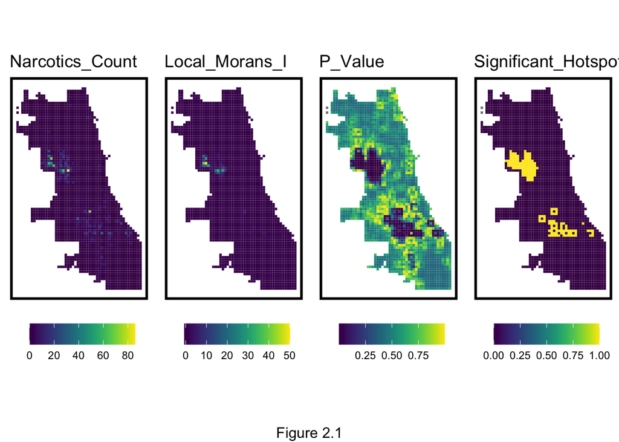

```r
vars <- unique(final_net.localMorans$Variable)
varList <- list()

for(i in vars){
  varList[[i]] <-
    ggplot() +
      geom_sf(data = filter(final_net.localMorans, Variable == i),
              aes(fill = Value), colour=NA) +
      scale_fill_viridis(name="") +
      labs(title=i) +
      mapTheme(title_size = 14) + theme(legend.position="bottom")}

do.call(grid.arrange,c(varList, ncol = 4, bottom = "Figure 2.1"))
```

```r
final_net <-
  final_net %>%
  mutate(narc.isSig =
           ifelse(localmoran(final_net$countNarc,
                             final_net.weights)[,5] <= 0.0000001, 1, 0)) %>%
  mutate(narc.isSig.dist =
           nn_function(st_coordinates(st_centroid(final_net)),
                       st_coordinates(st_centroid(
                         filter(final_net, narc.isSig == 1))), 1))
```

## Correlation

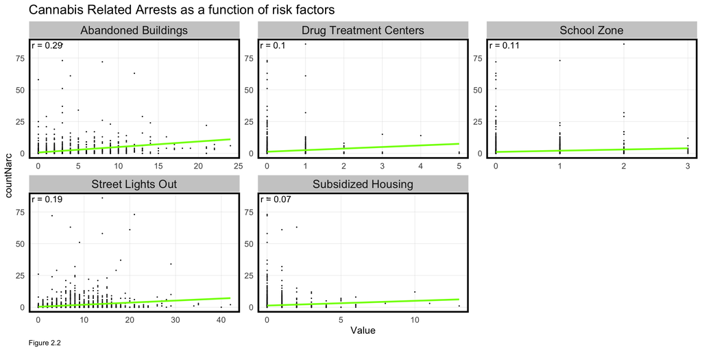

```r
correlation.long <-
  st_drop_geometry(final_net) %>%
    dplyr::select(-uniqueID, -cvID, -name, -District, -abandonBuildings.nn, -schools.nn, -streetLightsOut.nn, -treatmentCenters.nn, -affordableHousing.nn, -narc.isSig, -narc.isSig.dist) %>%
    gather(Variable, Value, -countNarc)

correlation.cor <-
  correlation.long %>%
    group_by(Variable) %>%
    summarize(correlation = cor(Value, countNarc, use = "complete.obs"))

ggplot(correlation.long, aes(Value, countNarc)) +
  geom_point(size = 0.1) +
  geom_text(data = correlation.cor, aes(label = paste("r =", round(correlation, 2))),
            x=-Inf, y=Inf, vjust = 1.5, hjust = -.1) +
  geom_smooth(method = "lm", se = FALSE, colour = "chartreuse") +
  facet_wrap(~Variable, ncol = 3, scales = "free") +
  labs(title = "Cannabis Related Arrests as a function of risk factors", caption = "Figure 2.2") +
  plotTheme()
```

## Distribution

Given that cannabis-related arrests represents less than 3% of arrests in this study, it is reasonable for most grid cells to contain no crime events. However, that is likely not the whole story. This histogram is a strong representation of why studying data spatially is critical to uncovering a more complete narrative. Is there a pattern among the few cells that do have arrests? Is it a coincidence that the few cells that record cannabis-related events are in predominantly nonwhite areas?

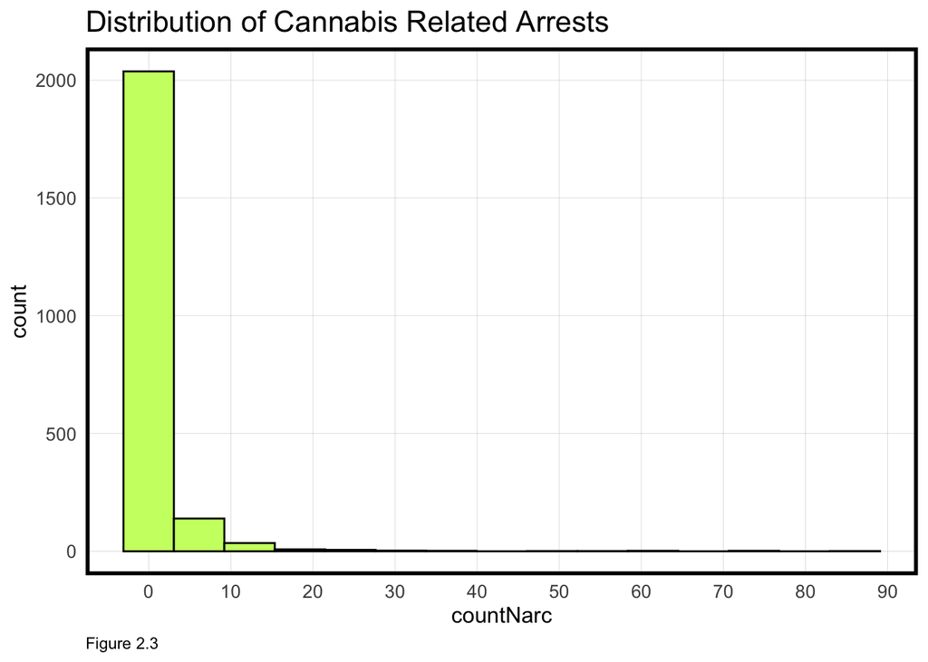

```r
ggplot(data = final_net, aes(countNarc))+
  geom_histogram(bins = 15, color = 'black', fill = "#CAFF70") +
  scale_x_continuous(breaks = seq(0, 100, by = 10)) +
  labs(title = 'Distribution of Cannabis Related Arrests', caption = "Figure 2.3") +
  plotTheme()
```

# **Accuracy & Generalizability**

## Map of Model Errors

Mapping the model errors by random k-fold and spatial cross validation can help examine how the model’s errors are distributed across different spatial locations to assess whether the model is consistently underperforming or over performing in specific geographic areas. While the random k-fold model suggests a more even distribution of error,the spatial cross validation strongly indicates the model is underperforming (highest mean absolute errors) in areas with the highest arrest rates. Ideally, identifying spatial patterns in prediction inaccuracies can help refine the model to account for or mitigate any spatial biases.

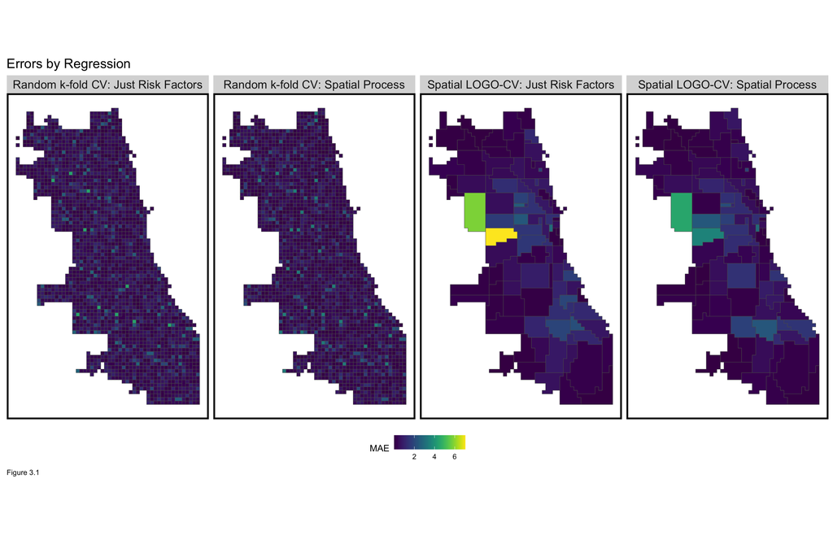

```r
reg.ss.vars <- c("abandonBuildings.nn", "schools.nn", "streetLightsOut.nn", "affordableHousing.nn", "treatmentCenters.nn", "narc.isSig", "narc.isSig.dist")

reg.vars <- c("abandonBuildings.nn", "schools.nn", "streetLightsOut.nn", "affordableHousing.nn", "treatmentCenters.nn")


## RUN REGRESSIONS
reg.cv <- crossValidate(
  dataset = final_net,
  id = "cvID",
  dependentVariable = "countNarc",
  indVariables = reg.vars) %>%
    dplyr::select(cvID = cvID, countNarc, Prediction, geometry)

reg.ss.cv <- crossValidate(
  dataset = final_net,
  id = "cvID",
  dependentVariable = "countNarc",
  indVariables = reg.ss.vars) %>%
    dplyr::select(cvID = cvID, countNarc, Prediction, geometry)

reg.spatialCV <- crossValidate(
  dataset = final_net,
  id = "name",
  dependentVariable = "countNarc",
  indVariables = reg.vars) %>%
    dplyr::select(cvID = name, countNarc, Prediction, geometry)

reg.ss.spatialCV <- crossValidate(
  dataset = final_net,
  id = "name",
  dependentVariable = "countNarc",
  indVariables = reg.ss.vars) %>%
    dplyr::select(cvID = name, countNarc, Prediction, geometry)

reg.summary <-
  rbind(
    mutate(reg.cv,           Error = Prediction - countNarc,
                             Regression = "Random k-fold CV: Just Risk Factors"),

    mutate(reg.ss.cv,        Error = Prediction - countNarc,
                             Regression = "Random k-fold CV: Spatial Process"),

    mutate(reg.spatialCV,    Error = Prediction - countNarc,
                             Regression = "Spatial LOGO-CV: Just Risk Factors"),

    mutate(reg.ss.spatialCV, Error = Prediction - countNarc,
                             Regression = "Spatial LOGO-CV: Spatial Process")) %>%
    st_sf()

error_by_reg_and_fold <-
  reg.summary  %>%
    group_by(Regression, cvID) %>%
    summarize(Mean_Error = mean(Prediction - countNarc, na.rm = T),
              MAE = mean(abs(Mean_Error), na.rm = T),
              SD_MAE = mean(abs(Mean_Error), na.rm = T)) %>%
  ungroup()

error_by_reg_and_fold %>%
  # filter(str_detect(Regression, "LOGO")) %>%
  ggplot() +
  geom_sf(aes(fill = MAE)) +
  facet_wrap(~Regression, ncol = 4) +
  scale_fill_viridis() +
  labs(title = "Errors by Regression", caption = "Figure 3.1") +
  mapTheme() + theme(legend.position="bottom")
```

## MAE Distribution

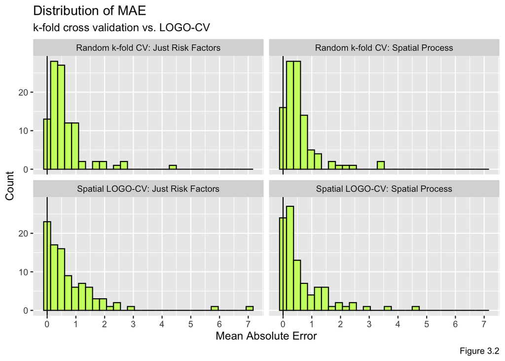

```r
neighborhood.weights <-
  filter(error_by_reg_and_fold, Regression == "Spatial LOGO-CV: Spatial Process") %>%
    group_by(cvID) %>%
      poly2nb(as_Spatial(.), queen=TRUE) %>%
      nb2listw(., style="W", zero.policy=TRUE)

error_by_reg_and_fold %>%
  ggplot(aes(MAE)) +
  geom_histogram(bins = 30, colour="black", fill = "#CAFF70") +
  facet_wrap(~Regression) +
  geom_vline(xintercept = 0) + scale_x_continuous(breaks = seq(0, 8, by = 1)) +
  labs(title="Distribution of MAE", subtitle = "k-fold cross validation vs. LOGO-CV", caption ="Figure 3.2",
       x="Mean Absolute Error", y="Count")
```

```r
 st_drop_geometry(error_by_reg_and_fold) %>%
  group_by(Regression) %>%
  summarize(Mean_MAE = round(mean(MAE), 2),
            SD_MAE = round(sd(MAE), 2)) %>%
  kable(caption = "MAE by regression") %>%
  kable_styling("striped", full_width = F, position = "left") %>%
    row_spec(2, color = "black", background = "#CAFF70") %>%
    row_spec(4, color = "black", background = "#CAFF70")
```

MAE by regression

| Regression | Mean_MAE | SD_MAE |
| --- | --- | --- |
| Random k-fold CV: Just Risk Factors | 0.62 | 0.66 |
| Random k-fold CV: Spatial Process | 0.56 | 0.60 |
| Spatial LOGO-CV: Just Risk Factors | 0.79 | 1.06 |
| Spatial LOGO-CV: Spatial Process | 0.65 | 0.80 |

## Errors by Race Context

As discussed at the beginning of the study, Chicago is highly segregated by race. Does the algorithm generalize across different neighborhood contexts? The following table suggests that low mean errors indicate a generalizable model. Furthermore, the model on average under-predicts in majority non-white and over-predicts in majority white neighborhoods. However, we cannot be sure that the model doesn’t suffer from selection bias considering the CPD’s systematic over-policing of non-white neighborhoods.

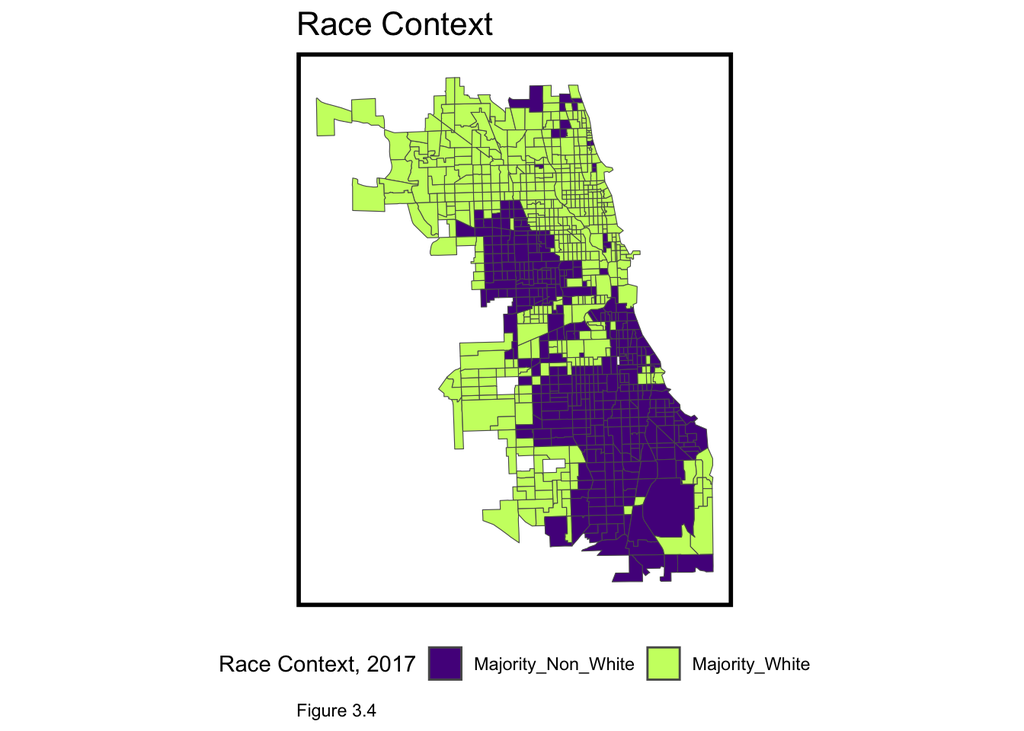

```r
census_api_key("c49a9145a5cad600a8b6393d31dbed862a0211a1", overwrite = TRUE, install = TRUE)

nonwhite <-
  get_acs(geography = "tract", variables = c("B01001_001E","B01001A_001E"),
          year = 2017, state=17, county=031, geometry=T) %>%
  st_transform('ESRI:102271')  %>%
  dplyr::select(variable, estimate, GEOID) %>%
  spread(variable, estimate) %>%
  rename(TotalPop = B01001_001,
         NumberWhites = B01001A_001) %>%
  mutate(percentWhite = NumberWhites / TotalPop,
         raceContext = ifelse(percentWhite > .5, "Majority_White", "Majority_Non_White")) %>%
  .[neighborhoods,]

ggplot() + geom_sf(data = na.omit(nonwhite), aes(fill = raceContext)) +
  scale_fill_manual(values = c("#551A8B", "#CAFF70"), name="Race Context, 2017") +
  labs(title = "Race Context", caption = "Figure 3.4") +
  mapTheme() + theme(legend.position="bottom")
```

```r
reg.summary %>%
    filter(str_detect(Regression, "Spatial Process")) %>%
    st_centroid() %>%
    st_join(nonwhite) %>%
    na.omit() %>%
      st_drop_geometry() %>%
      group_by(Regression, raceContext) %>%
      summarize(mean.Error = mean(Error, na.rm = T)) %>%
      spread(raceContext, mean.Error) %>%
      kable(caption = "Mean Error by neighborhood racial context") %>%
      kable_styling("striped", full_width = F, position = "left") %>%
      row_spec(2, color = "black", background = "#CAFF70")
```

Mean Error by neighborhood racial context

| Regression | Majority_Non_White | Majority_White |
| --- | --- | --- |
| Random k-fold CV: Spatial Process | -0.1933073 | 0.2165304 |
| Spatial LOGO-CV: Spatial Process | -0.2777608 | 0.2231958 |

## Alternative Kernel Model

Traditionally, police target resources to places where crime is most concentrated, to ‘hotspots’ which are represented by a more traditional kernel density hotspot mapping. The map on the left shows a kernel density map showing a 1000 ft search radius. On the right, a new goodness of fit indicator is created to illustrate whether the 2017 kernel density or risk predictions capture more of the 2018 cannabis related arrests. High risk categories with few 2018 observed burglaries may suggest latent risk or a poorly fit model. Considering what we know about selection bias, it is not a map of the high density of cannabis usage - only arrests.

The risk categories come from predictions broken into five class intervals using Fisher’s natural breaks classification, `5th` being the most risky.

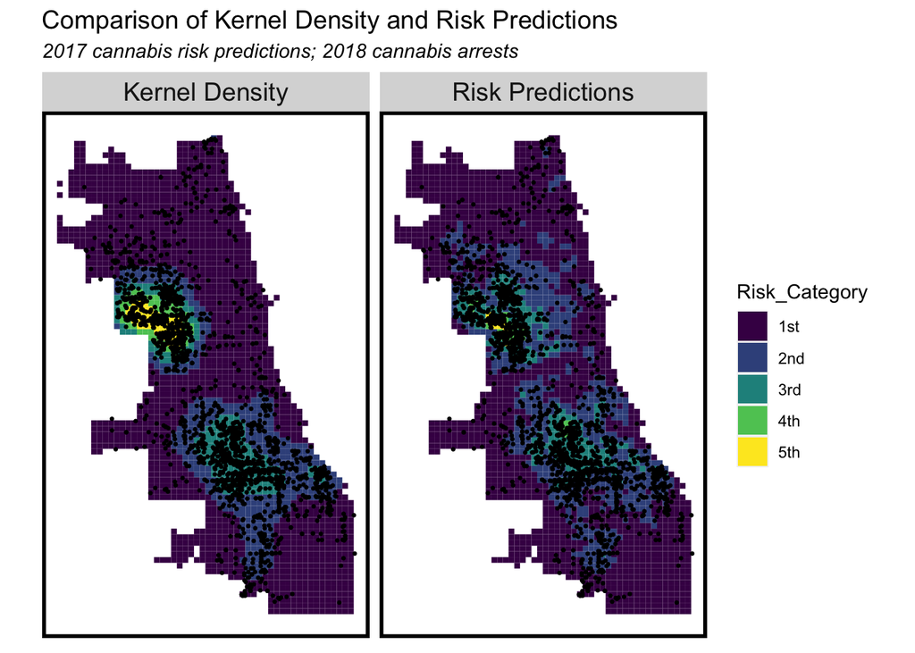

```r
narc_ppp <- as.ppp(st_coordinates(narc), W = st_bbox(final_net))
narc_KD.1000 <- density.ppp(narc_ppp, 1000)

narc18 <-
  read.socrata("https://data.cityofchicago.org/Public-Safety/Crimes-2018/3i3m-jwuy") %>%
  filter(Primary.Type == "NARCOTICS" & str_detect(Description, "CANNABIS")) %>%
  mutate(x = gsub("[()]", "", Location)) %>%
  separate(x,into= c("Y","X"), sep=",") %>%
  mutate(X = as.numeric(X),
         Y = as.numeric(Y)) %>%
  na.omit() %>%
  st_as_sf(coords = c("X", "Y"), crs = 4326, agr = "constant") %>%
  st_transform('ESRI:102271') %>%
  distinct() %>%
  .[fishnet,]


narc_KDE_sum <- as.data.frame(narc_KD.1000) %>%
  st_as_sf(coords = c("x", "y"), crs = st_crs(final_net)) %>%
  aggregate(., final_net, mean)
kde_breaks <- classIntervals(narc_KDE_sum$value,
                             n = 5, "fisher")
narc_KDE_sf <- narc_KDE_sum %>%
  mutate(label = "Kernel Density",
         Risk_Category = classInt::findCols(kde_breaks),
         Risk_Category = case_when(
           Risk_Category == 5 ~ "5th",
           Risk_Category == 4 ~ "4th",
           Risk_Category == 3 ~ "3rd",
           Risk_Category == 2 ~ "2nd",
           Risk_Category == 1 ~ "1st")) %>%
  cbind(
    aggregate(
      dplyr::select(narc18) %>% mutate(narcCount = 1), ., sum) %>%
    mutate(narcCount = replace_na(narcCount, 0))) %>%
  dplyr::select(label, Risk_Category, narcCount)


ml_breaks <- classIntervals(reg.ss.spatialCV$Prediction,
                             n = 5, "fisher")
narc_risk_sf <-
  reg.ss.spatialCV %>%
  mutate(label = "Risk Predictions",
         Risk_Category =classInt::findCols(ml_breaks),
         Risk_Category = case_when(
           Risk_Category == 5 ~ "5th",
           Risk_Category == 4 ~ "4th",
           Risk_Category == 3 ~ "3rd",
           Risk_Category == 2 ~ "2nd",
           Risk_Category == 1 ~ "1st")) %>%
  cbind(
    aggregate(
      dplyr::select(narc18) %>% mutate(narcCount = 1), ., sum) %>%
      mutate(narcCount = replace_na(narcCount, 0))) %>%
  dplyr::select(label,Risk_Category, narcCount)

rbind(narc_KDE_sf, narc_risk_sf) %>%
  na.omit() %>%
  gather(Variable, Value, -label, -Risk_Category, -geometry) %>%
  ggplot() +
    geom_sf(aes(fill = Risk_Category), colour = NA) +
    geom_sf(data = sample_n(narc18, 3000), size = .5, colour = "black") +
    facet_wrap(~label, ) +
    scale_fill_viridis(discrete = TRUE) +
    labs(title="Comparison of Kernel Density and Risk Predictions",
         subtitle="2017 cannabis risk predictions; 2018 cannabis arrests") +
    mapTheme(title_size = 14)
```

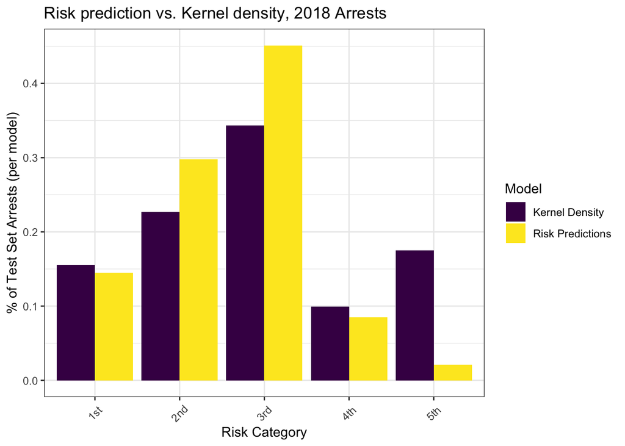

```r
rbind(narc_KDE_sf, narc_risk_sf) %>%
  st_drop_geometry() %>%
  na.omit() %>%
  gather(Variable, Value, -label, -Risk_Category) %>%
  group_by(label, Risk_Category) %>%
  summarize(countNarc = sum(Value)) %>%
  ungroup() %>%
  group_by(label) %>%
  mutate(Pcnt_of_test_set_crimes = countNarc / sum(countNarc)) %>%
    ggplot(aes(Risk_Category, Pcnt_of_test_set_crimes)) +
      geom_bar(aes(fill=label), position="dodge", stat="identity") +
      scale_fill_viridis(discrete = TRUE, name = "Model") +
      labs(title = "Risk prediction vs. Kernel density, 2018 Arrests",
           y = "% of Test Set Arrests (per model)",
           x = "Risk Category") +
  theme_bw() +
      theme(axis.text.x = element_text(angle = 45, vjust = 0.5))
```

# **Discussion**

The study suggests that the prediction model should not be used by the Chicago Police Department to resource its narcotics division.

Geospatial risk prediction mirrors past arrest patterns and tests whether that pattern generalizes to places where arrests may be high as a tool to allocate police resources.However, given the racialization of narcotic criminalization in combination with Chicago’s segregated neighborhoods, selection and spatial bias must be considered when assessing the model’s credibility. Additionally, it is important to note that arrests are not evenly distributed across all non-white neighborhoods. There are generally two significant hotspots. Understanding what sets those two areas apart could help uncover the nature of these arrests. However, we could not reliably add that variable as a risk factor to improve the model since it is unlikely that it generalizes across the whole city.

The statistical analysis presented in this model verifies the spatial bias of the data. For example, Local Moran’s I and the high distribution of errors in hotspot areas confirm that the model is not a reliable approach for cannabis-related crime prediction. Arrests and criminal narcotics activity are not one in the same. If the CPD was interested in reforming how it pursues narcotics offenses, it would be best to build a model based on resident drug usage survey data rather than past arrests.

As a result, I would not suggest extensive implementation of this algorithm in police departments without further scrutiny of biases and the spatial process of the crimes.